# STAT 440: Homework Assignment #5

Due: Thursday, Mar. 27 at 11:59pm on Canvas

Some of these exercises call for writing code. Please use R, and turn in your code along with your written work and any plots you are asked to produce. Just as you strive for clarity in your writing of language, try to write R code that is easy to read, in the sense that a knowledgeable user of R would be able to understand it easily.

You *may* choose to use LaTeX for your mathematics writing in your homework, in which case I recommend R Markdown as an easy way to combine text, mathematics, R code, and R output. But this is not required; you may choose to format your work however you find convenient, as long as you upload your assignment to Canvas as a single pdf document.

## Exercise 1: Build a naive Bayes classifier

As we discussed in class on March 17, the first homework question is based on the Week 08c notes and asks you to use naive Bayes to classify wines based on three quantitative variables.

The dataset is described here: https://archive.ics.uci.edu/dataset/109/wine

Here is the code we saw in class (posted on Canvas) for creating a `wine` object containing the full dataset:

```r
path <- "https://raw.githubusercontent.com/data-8/textbook/main/assets/data/"
wine <- read.csv(paste(path, "wine.csv", sep=""))
```

**Part (a)** Find a set of three variables to use for the classifier. You may use any of the 13 “Feature” variables as described at https://archive.ics.uci.edu/dataset/109/wine. (Even the two interger-valued variables may be treated as continuous for the purpose of this assignment, since each takes a wide range of integer values and may be considered to be continuous but rounded to the nearest integer)

In class, I used columns 2, 3, and 5 after examining scatterplot pairs. I was looking for variables that seem to allow a pretty good separation among the three classes in one or more scatterplots when the plots distinguish among the three classes, as in this example from class:

```r
# Use colors, based on the wine categories, to distinguish types of wine:
pairs(wine[,c(2, 3, 5)], col=wine$Class)
```

After a bit of exploratory data analysis, select the three variables you will use (do not use exactly the same set of variables 2, 3, and 5) and then give both a one-or-two sentence description of why these seem reasonable along with an array of scatterplots showing the variables you’ve selected.

**Part (b)** This naive Bayes classifier should assume a normal distribution for each variable’s marginal distribution in each of the three categories. This means we can fully describe each marginal for each category (nine marginals in all) by just two parameters, the mean and variance.

Let’s introduce some notation: $\mu_{ij}$ and $\sigma^2_{ij}$ be the mean and variance, respectively, of the $i$th variable for the $j$th category, where $i$ and $j$ can each be 1, 2, or 3. You should estimate each of these using the usual sample means and variances.

Write code to do this, then express your 18 estimates—nine $\hat\mu_{ij}$ and nine $\hat\sigma^2_{ij}$—in some kind of a table format (you can decide what format makes the most sense).

Incidentally, this estimation phase is the “training” of the Bayes classifier.

**Part (c)** This part is purely analytical. Take a look at the Bayes’ Theorem formula from Week 08c, which is reproduced here:
$$P(C=1 | X_1, \ldots, X_p) = \frac{P(X_1, \ldots, X_p | C=1)P(C=1)}
{P(X_1, \ldots, X_p | C=1)P(C=1) + \cdots +
P(X_1, \ldots, X_p | C=k)P(C=k)}.$$
(Notice: In your case, $p=3$ and $k=3$; do you see why? Furthermore, you can derive a similar formula for the conditional probabilities that $C=2$ and $C=3$.)

First, let’s assume that, *a priori*, no category is more likely than any other category. This means that the prior probability for the $i$th category, $P(C=i)$, equals 1/3 for each $i$. Second, make both of the simplifying assumptions from Week 08c, which are
$$P(X_1, X_2, X_3 | C=j) =
P(X_1 | C=j) \times P(X_2 | C=j)\times P(X_3 | C=j)$$
and
$$P(X_i | C=j) =
\frac{1}{\hat\sigma_{ij}\sqrt{2\pi}}
\exp\left\{ \frac{-1}{2\hat\sigma_{ij}^2} (X_i - \hat\mu_i)^2 \right\}$$
for $i=1, 2, 3$ and $j=1, 2, 3$.

Simplify an expression for $P(C=1 | X_1, X_2, X_3)$. It should involve all of your $\hat\mu_{ij}$ and $\hat\sigma^2_{ij}$ values, which you should leave as their Greek-letter versions, rather than their numerical values found in part (b), for now.

**Part (d)** Now write code that will take any values of your three variables, $X_1$, $X_2$, and $X_3$, then return the conditional probabilities of $C=1$, $C=2$, and $C=3$ given those values. This code should be based on the simplified expression in part (c).

Run this code on each of the 178 rows in the wine dataset. For how many of these rows is the most likely wine category predicted by your classifier the same as the actual wine category of that row?

**Part (e)** Now implement three-fold cross-validation: Randomly divide the 178 rows into groups of sizes 59, 59, and 60 as follows:

```r
set.seed(440)
GroupA <- sample(1:178, 59)
GroupB <- sample((1:178)[-GroupA], 59)
GroupC <- (1:178)[-c(GroupA, GroupB)]
```

(Make sure you understand the logic of the above code.)

Redo the training from part (b) using only the rows in Group A and Group B; in other words, using `wine[c(GroupA, GroupB),]`. Then test the Group C rows to see how many of the predictions for Group C match the true categories for Group C.

Repeat this process using

1. training data `wine[c(GroupA, GroupC),]` and test data `wine[GroupB,]`;
2. training data `wine[c(GroupB, GroupC),]` and test data `wine[GroupA,]`.

In total, how many of your predictions matched the truth? This answer is a better measure of the success of your naive Bayes classifier than your answer to part (d).

### Answer

```r
library(tidyverse)
```

**Part (a)**

```r
path <- "https://raw.githubusercontent.com/data-8/textbook/main/assets/data/"
wine <- read.csv(paste(path, "wine.csv", sep=""))
names(wine)
```

```
##  [1] "Class"                        "Alcohol"
##  [3] "Malic.Acid"                   "Ash"
##  [5] "Alcalinity.of.Ash"            "Magnesium"
##  [7] "Total.Phenols"                "Flavanoids"
##  [9] "Nonflavanoid.phenols"         "Proanthocyanins"
## [11] "Color.Intensity"              "Hue"
## [13] "OD280.OD315.of.diulted.wines" "Proline"
```

```r
table(wine$Class)
```

```
##
##  1  2  3
## 59 71 48
```

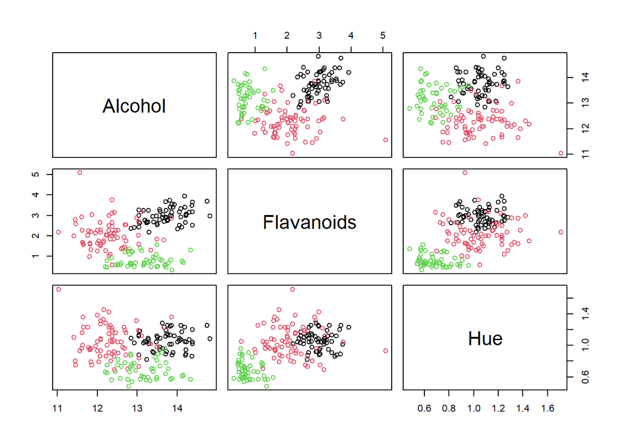

```r
pairs(wine[,c(2,8,12)], col=wine$Class)
```

I am choosing the variables Alcohol, Flavanoids, and Hue. I am choosing these variables because when looking at the scatter plots, they all appear to be pretty easily separated. Since there are three distinct zones where the different classes lie, these three variables should be a good choice for a naive Bayes’ classifier.

**Part (b)** Now we are required to “train” the model. This means that we need to find the mean and standard deviation for each variable for each class. Since we have three variables and three classes, this will result in nine estimates of both the mean and the standard deviation.

```r
wine <-
  wine |>
  select(c(2,8,12,1)) #overwrite the dataframe, with our selected variables and the true label for classifying

muHat <-
  wine |>
  group_by(Class) |>
  summarise(alcoholMeans = mean(Alcohol),
            flavonoidsMeans = mean(Flavanoids),
            hueMean = mean(Hue))
sigmaHat <-
  wine |>
  group_by(Class) |>
  summarise(alcoholSD = sd(Alcohol),
            flavonoidsSD = sd(Flavanoids),
            hueSD = sd(Hue))

muHat
```

| Class | alcoholMeans | flavonoidsMeans | hueMean |
| --- | --- | --- | --- |
| 1 | 13.74475 | 2.9823729 | 1.0620339 |
| 2 | 12.27873 | 2.0808451 | 1.0562817 |
| 3 | 13.15375 | 0.7814583 | 0.6827083 |

```r
sigmaHat
```

| Class | alcoholSD | flavonoidsSD | hueSD |
| --- | --- | --- | --- |
| 1 | 0.4621254 | 0.3974936 | 0.1164826 |
| 2 | 0.5379642 | 0.7057008 | 0.2029368 |
| 3 | 0.5302413 | 0.2935041 | 0.1144411 |

**Part(c)**

To simplify the equation for $P(C=1|X_1,X_2,X_3)$, we need to rewrite Bayes’ equation with our specific variables plugged in. Since we set the prior to be 1/3 for all classes of wine, we can cancel out all of the prior terms in the equation.

$P(C=1|X_1,X_2,X_3)=\frac{P(X_1,X_2,X_3|C=1)}{P(X_1,X_2,X_3|C=1) + P(X_1,X_2,X_3|C=2)+P(X_1,X_2,X_3|C=3)}$

Since we are also assuming independence, we know that: $P(X_1,X_2,X_3|C=j)=P(X_1|C=j)\times P(X_2|C=j)\times P(X_3|C=j)$

So then we will have: $P(C=1|X_1,X_2,X_3)=\frac{P(X_1|C=1)\times P(X_2|C=1)\times P(X_3|C=1)}{(P(X_1|C=1)\times P(X_2|C=1)\times P(X_3|C=1)) + (P(X_1|C=2)\times P(X_2|C=2)\times P(X_3|C=2))+(P(X_1|C=3)\times P(X_2|C=3)\times P(X_3|C=3))}$

Since we are using a normal distribution for each variables marginal distribution, we can plug in the normal density function for each of the terms in the equation.

$P(C=1|X_1,X_2,X_3)=\frac{\frac1{\hat{\sigma}_{1,1}\sqrt{2\pi}}e^{\frac{-(X_1-\hat{\mu}_1)^2}{2\hat{\sigma}_{1,1}}}\times \frac1{\hat{\sigma}_{2,1}\sqrt{2\pi}}e^{\frac{-(X_2-\hat{\mu}_2)^2}{2\hat{\sigma}_{2,1}}}\times \frac1{\hat{\sigma}_{3,1}\sqrt{2\pi}}e^{\frac{-(X_3-\hat{\mu}_3)^2}{2\hat{\sigma}_{3,1}}}}{(\frac1{\hat{\sigma}_{1,1}\sqrt{2\pi}}e^{\frac{-(X_1-\hat{\mu}_1)^2}{2\hat{\sigma}_{1,1}}}\times \frac1{\hat{\sigma}_{2,1}\sqrt{2\pi}}e^{\frac{-(X_2-\hat{\mu}_2)^2}{2\hat{\sigma}_{2,1}}}\times \frac1{\hat{\sigma}_{3,1}\sqrt{2\pi}}e^{\frac{-(X_3-\hat{\mu}_3)^2}{2\hat{\sigma}_{3,1}}}) + (\frac1{\hat{\sigma}_{1,2}\sqrt{2\pi}}e^{\frac{-(X_1-\hat{\mu}_1)^2}{2\hat{\sigma}_{1,2}}}\times \frac1{\hat{\sigma}_{2,2}\sqrt{2\pi}}e^{\frac{-(X_2-\hat{\mu}_2)^2}{2\hat{\sigma}_{2,2}}}\times \frac1{\hat{\sigma}_{3,2}\sqrt{2\pi}}e^{\frac{-(X_3-\hat{\mu}_3)^2}{2\hat{\sigma}_{3,2}}})+(\frac1{\hat{\sigma}_{1,3}\sqrt{2\pi}}e^{\frac{-(X_1-\hat{\mu}_1)^2}{2\hat{\sigma}_{1,3}}}\times \frac1{\hat{\sigma}_{2,3}\sqrt{2\pi}}e^{\frac{-(X_2-\hat{\mu}_2)^2}{2\hat{\sigma}_{2,3}}}\times \frac1{\hat{\sigma}_{3,3}\sqrt{2\pi}}e^{\frac{-(X_3-\hat{\mu}_3)^2}{2\hat{\sigma}_{3,3}}})}$

This big ugly equation can be simplified significantly by turning it into a term that uses product and sum notation, we can also cancel out the $\frac 1{\sqrt{2\pi}}$ term that appears.

$P(C=1 | X_1, X_2, X_3) = \frac{\prod_{i=1}^{3} \frac{1}{\hat{\sigma}_{i,1}} e^{-\frac{(X_i -\hat{\mu}_i)^2}{2\hat{\sigma}_{i,1}^2}}}{\sum_{j=1}^{3} \prod_{i=1}^{3} \frac{1}{\hat{\sigma}_{i,j}} e^{-\frac{(X_i -\hat{\mu}_i)^2}{2\hat{\sigma}_{i,j}^2}}}$

**Part (d)**

Setting up for Cross Validation

```r
set.seed(440)
GroupA <- sample(1:178, 59)
GroupB <- sample((1:178)[-GroupA], 59)
GroupC <- (1:178)[-c(GroupA, GroupB)]
```

```r
compute_class_probabilities <- function(X, mu, sigma) {
  # X: A vector of feature values
  # mu: matrix where each row corresponds to a class, and columns are means of features
  # sigma: matrix where each row corresponds to a class, and columns are SD of features

  numClasses <- nrow(mu)  # Number of classes
  numFeatures <- length(X) # Number of features

  likelihoods <- rep(0,numClasses)

  for (c in 1:numClasses) {
    means <- mu[c, ]
    sds <- sigma[c, ]

    likelihoods[c] <- prod(dnorm(X, mean = means, sd = sds))
  }

  # Compute posterior probabilities for each class
  posterior <- likelihoods / sum(likelihoods)

  return(posterior)
}
```

```r
correct <- 0

# Loop through each row of the wine dataset
for (i in 1:nrow(wine)) {
  X <- as.numeric(wine[i, -4])

  # Get the actual class for row
  actual <- wine$Class[i]

  # Compute the conditional probabilities for current row
  posterior <- compute_class_probabilities(X, as.matrix(muHat[,-1]), as.matrix(sigmaHat[,-1]))

  predict <- which.max(posterior)

  # Compare the predicted with the actual
  if (predict == actual) {
    correct <- correct + 1
  }
}

correct
```

```
## [1] 173
```

Here we see that we have correctly predicted 173 of the 178 wines in the dataset correctly. This is an accuracy of 97.2% which is very good.

**Part (e)**

Now, we will use 3-fold cross validation

```r
correctCV <- 0

for (fold in 1:3) {
  # Define the training and validation sets for each fold
  if (fold == 1) {
    train_indices <- c(GroupB, GroupC)
    valid_indices <- GroupA
  } else if (fold == 2) {
    train_indices <- c(GroupA, GroupC)
    valid_indices <- GroupB
  } else {
    train_indices <- c(GroupA, GroupB)
    valid_indices <- GroupC
  }

  # Subset the wine data for training and validation
  train_data <- wine[train_indices, ]
  valid_data <- wine[valid_indices, ]

  # Train the model (calculate muHat and sigmaHat for the training data)
  muHatCV <-
  train_data |>
  group_by(Class) |>
  summarise(alcoholMeans = mean(Alcohol),
            flavonoidsMeans = mean(Flavanoids),
            hueMean = mean(Hue))
  sigmaHatCV <-
    train_data |>
    group_by(Class) |>
    summarise(alcoholSD = sd(Alcohol),
              flavonoidsSD = sd(Flavanoids),
              hueSD = sd(Hue))

  # Validate on the validation set
  for (i in 1:nrow(valid_data)) {
    Xcv <- as.numeric(valid_data[i, -4])  # Extract features for validation

    # Get the actual class for the current row
    actualCV <- valid_data$Class[i]

    # Compute the conditional probabilities for the current row
    posteriorCV <- compute_class_probabilities(Xcv, as.matrix(muHatCV[,-1]), as.matrix(sigmaHatCV[,-1]))

    # Get the predicted class as the one with the highest probability
    predictedCV <- which.max(posteriorCV)

    # Compare the predicted class with the actual class
    if (predictedCV == actualCV) {
      correctCV <- correctCV + 1
    }
  }
}

# Output the accuracy of the model after 3-fold cross-validation
accuracy <- correctCV / nrow(wine)
accuracy
```

```
## [1] 0.9494382
```

This resulted in a slightly smaller accuracy than training on the entire dataset, but an accuracy of 94.94% is still very good for a classifier.

## Exercise 2: Implement a Metropolis-Hastings Sampler

In the Bayesian normal model discussed in Week 08a notes, two facts are established in the case where $X\sim N(\mu, \sigma^2)$: First, if $\sigma^2$ is known, then a normal prior on $\mu$ is a conjugate prior; second, if $\mu$ is known, then an inverse gamma prior on $\sigma^2$ is a conjugate prior.

However, neither of these cases is particularly realistic, since we usually don’t know either $\mu$ or $\sigma$. This exercise will consider the case where we assume *a priori* that $\mu$ and $\sigma^2$ are independent with $\mu\sim N(0,1)$ and $\sigma^2\sim IG(1, 1)$. In other words, the joint prior is the product of the two marginal densities, normal for $\mu$ and inverse gamma for $\sigma^2$, so the prior is
$$\pi(\mu,\sigma^2) \propto \exp\left\{ -\frac{\mu^2}{2} \right\} \times
(\sigma^2)^{-2} \exp\left\{ -\frac{1}{\sigma^2} \right\}.$$
This prior on $(\mu,\sigma^2)$ is *not* a conjugate prior because in the posterior, $\mu$ and $\sigma^2$ are not independent. Nonetheless, this prior seems reasonable, and the goal of this exercise will be to produce approximate draws from the posterior.

**Part (a)** To keep things simple, assume that the data only consist of a single $X\sim N(\mu, \sigma^2)$ rather than, say, an iid sample of size $n$.

You know that the likelihood in this case is a normal density function of $X$ with mean $\mu$ and variance $\sigma^2$. You also know that the posterior joint density for $(\mu,\sigma^2)$ is proportional to the likelihood times the prior. Based on these facts, supposing that we observe $X=1.2$, write down a function that is proportional to the posterior.

**Part (b)** To implement a Metropolis-Hastings algorithm requires a proposal distribution. This is a distribution based on $(\mu_{\rm current}, \sigma^2_{\rm current})$ from which you’ll simulate $(\mu_{\rm proposed}, \sigma^2_{\rm proposed})$. In the Week 08b notes, this proposal density is denoted by $Q$.

Again, to keep things simple, let’s choose a proposal distribution that is symmetric, such as a bivariate normal distribution with zero correlation.

This symmetry means that
$$Q \left[ (\mu_c, \sigma^2_c) | (\mu_p, \sigma^2_p) \right] =
Q \left[ (\mu_p, \sigma^2_p) | (\mu_c, \sigma^2_c) \right]$$
where of course “c” means current and “p” means proposed. This means that the M-H acceptance probability (again, see the Week 08b notes) reduces to
$$A \left[ (\mu_c, \sigma^2_c) , (\mu_p, \sigma^2_p) \right] =
\min \left\{ 1, \frac{f[(\mu_p, \sigma^2_p)]}{f[(\mu_c,
\sigma^2_c)]}\right\}.$$
Here, $f$ is the posterior, because of the ratio of two $f$ values, anything proportional to the posterior will work just as well—which is why the answer from part (a) can be used as $f$.

Write code that implements 10,000 iterations as follows:

1. Initialize $\mu_c = 0$ and $\sigma^2_c=1$.
2. Define $\mu_p = \mu_c + A$ and $\sigma^2_p = \sigma^2_c + B$, where $A$ and $B$ are independent normal random variables with mean 0 and standard deviation 0.1.
3. Calculate $A\left[ (\mu_c, \sigma^2_c) , (\mu_p, \sigma^2_p) \right]$ as above.
4. Generate standard uniform $U$.
5. If $U<A\left[ (\mu_c, \sigma^2_c) , (\mu_p, \sigma^2_p) \right]$, replace $\mu_c$ by $\mu_p$ and $\sigma^2_c$ by $\sigma^2_p$.
6. Record the values of $(\mu_c, \sigma^2_c)$, whether or not your replaced them with the new proposals in step 5.
7. Return to step 2.

**Part (c)** Create a 2-dimensional scatterplot of the 10,000 recorded values of $(\mu_c, \sigma^2_c)$. This is your approximate sample from the posterior distribution.

### Answer

**Part (a)**

Since the data is known to be a single point, we know that the likelihood function is the same as the mass function for the distribution.

$L(X| \mu, \sigma^2) = \frac1{\sqrt{\sigma^2}}e^{-(X-\mu)^2/2\sigma^2}$

We are also given that the marginal priors for the parameters are proportional to:

$e^{-\frac{\mu^2}2} \times (\sigma^2)^{-2} e^{-\frac1{\sigma^2}}$

Since we also know that the posterior distribution will be proportional to the likelihood times the prior.

$\text p[(\mu,\sigma^2)|X] \propto e^{-\frac{\mu^2}2}(\sigma^2)^{-2} e^{-\frac1{\sigma^2}}\frac1{\sqrt{\sigma^2}}e^{-(X-\mu)^2/2\sigma^2}$

After observing that X = 1.2, we get: $e^{-\frac{\mu^2}2}(\sigma^2)^{-2} e^{-\frac1{\sigma^2}}\frac1{\sqrt{\sigma^2}}e^{-(1.2-\mu)^2/2\sigma^2}$

**Part (b)**

We are going to use a proposal distribution that is symmetric and non-correlated. Using a bivariate normal distribution is a good suggestion for the proposal. Since there is no correlation and they are symmetric, this means that the transition probability of going from the current state to the proposed state is equal to the transition probability of going from the proposed state to the current state. This means that the transition terms in the acceptance probability will cancel out, reducing this just to a Metropolis sampler.

So our acceptance probability will be: $A[ (\mu_c, \sigma^2_c) , (\mu_p, \sigma^2_p)] = \min(1, \frac{f[(\mu_p, \sigma^2_p)]}{f[(\mu_c, \sigma^2_c)]})$

where $f(\mu, \sigma^2)$ is our posterior distribution.

Now we will implement the sampler for 10 000 iterations

```r
f <- function (mu, sigsq) {
  dnorm(mu) *
  1/sigsq^2 * exp(-1/sigsq) * (sigsq > 0) *
  exp(-(1.2-mu)^2 / (2 * sigsq))
  }

# Step 1: Initialization (remember, C mean current and P means proposed)
muC <- 0 ; sigsqC <- 1
samples <- data.frame(mu = numeric(10000), sigsq = numeric(10000))

set.seed(440)



for (i in 1:10000) {
  # Step 2: Generate proposed values
  muP <- muC + rnorm(1)/10
  sigsqP <- sigsqC + rnorm(1)/10

  # Step 3: Calculate the acceptance ratio
  A <- f(muP, sigsqP) / f(muC, sigsqC)

  # Steps 4 and 5: Generate U~unif(0,1) and compare with A

  if ( (U<-runif(1)) < A ) {
    muC <- muP
    sigsqC <- sigsqP
  }
  samples[i, ] <- c(muC, sigsqC)#store values of mu and sigsq current
}
```

**Part (c)**

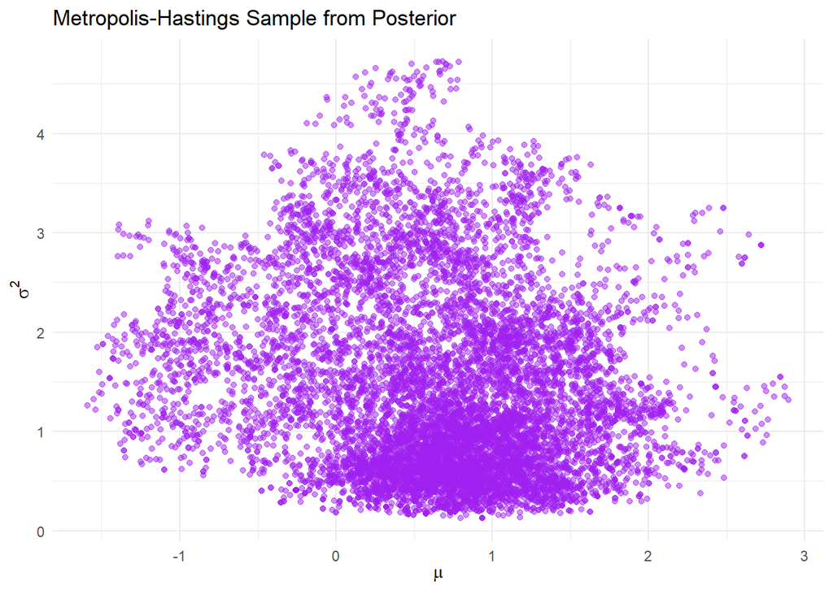

```r
ggplot(samples, aes(x = mu, y = sigsq)) +
  geom_point(alpha = 0.5, color = "purple") +
  labs(x = expression(mu), y = expression(sigma^2),
       title = "Metropolis-Hastings Sample from Posterior") +
  theme_minimal()
```